# **RBSI Visualization and Interpretation Lab**

### More aesthetic changes

The plot we produced is legible and shows the relationship between life expectancy and GDP per capita. But, we could do some changes to make it look better or present some additional information we have in our dataset.

1. Let’s make the point’s size show the population of each country-year. For that, we will add the *size* option in the *aes* options. Always be conscious about the number of parenthesis.

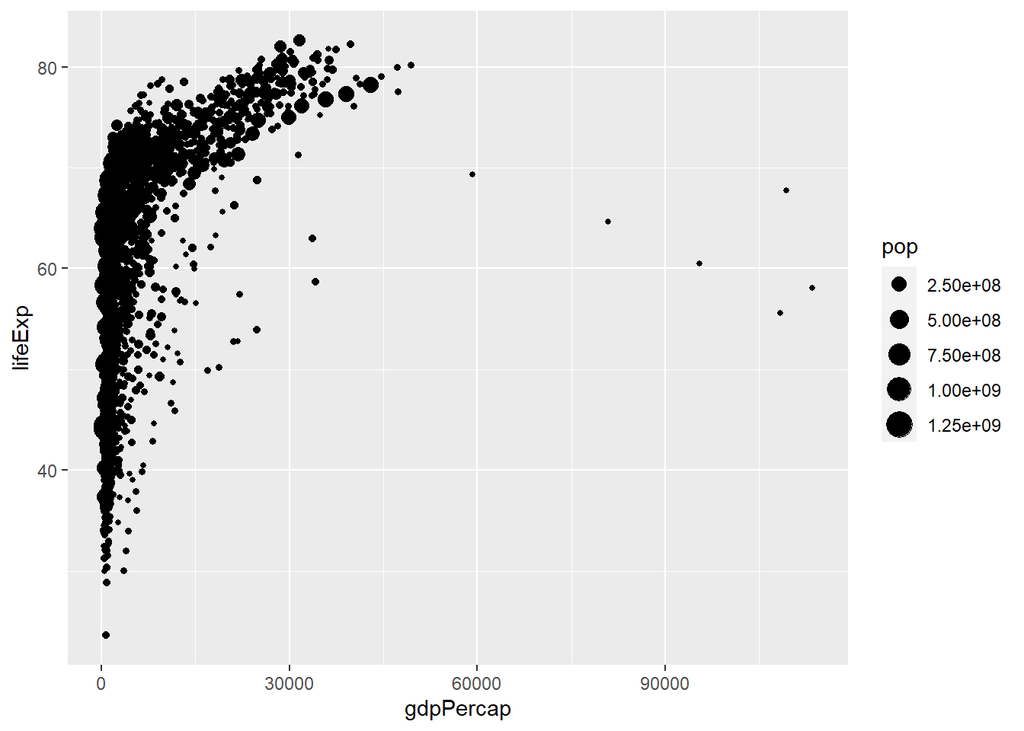

```r
p1 <- ggplot(data= gapminder,                              # dataset you want to use
            mapping = aes(x = gdpPercap, y = lifeExp,      # Define axis
                          size = pop)) +                   # Make size change with the population
   geom_point()                                            # adding points
p1
```

If we look closer, we can see that the points now have different sizes depending on the country’s population size.

2. Let’s make the color of the points show the continent of each observation.

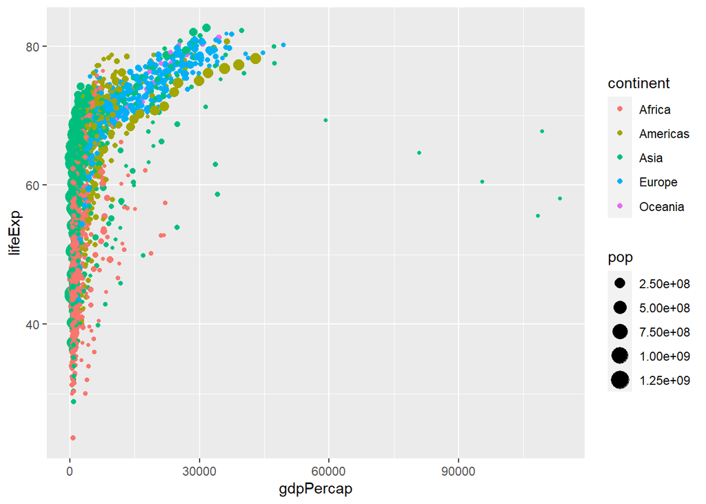

```r
p1 <- ggplot(data= gapminder,                              # dataset you want to use
            mapping = aes(x = gdpPercap, y = lifeExp,      # Define axis
                          size = pop,                      # Make size change with the population
                          color = continent)) +            # Make color change with the country's continent
   geom_point()                                            # adding points
p1
```

3. We can also change the attributes of the points themselves, like their shape, size and color by adding attributes to the *geom_point* function

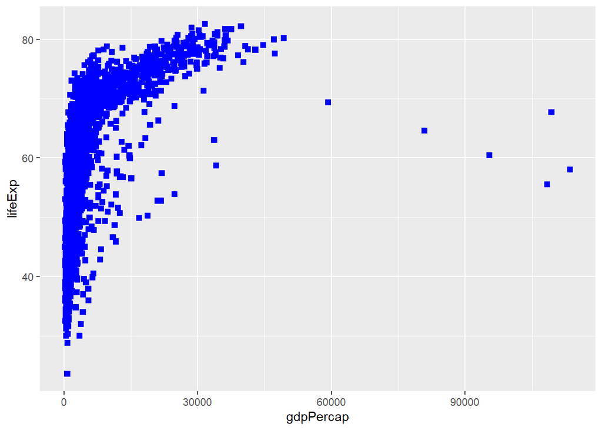

```r
p1 <- ggplot(data= gapminder,                              # dataset you want to use
            mapping = aes(x = gdpPercap, y = lifeExp)) +   # axis
   geom_point(shape = 15,                                  # Shape of the points, try these numbers 0, 1, 2, 3, 4, 10, 14
              color = "blue",                              # color, you can write the color or use a hex number
              size = 2)                                    # size of the dots
p1
```

4. We can even change the shading of the points given changes in other variables

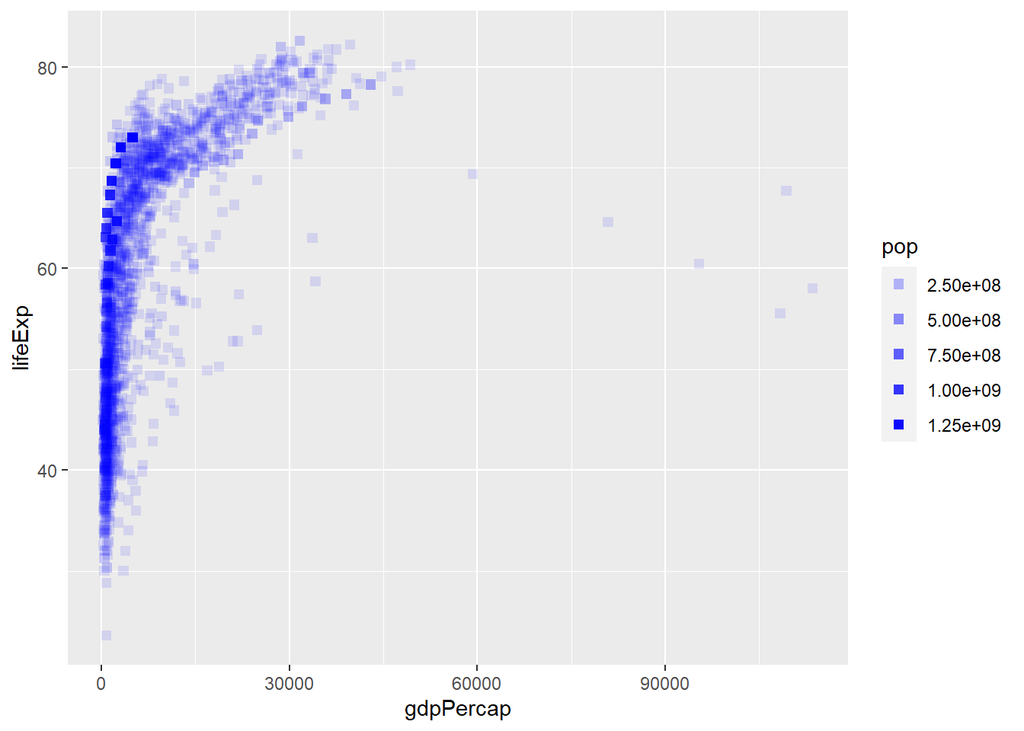

```r
p1 <- ggplot(data= gapminder,                              # dataset you want to use
            mapping = aes(x = gdpPercap, y = lifeExp)) +   # axis
   geom_point(shape = 15,                                  # Shape of the points, try these numbers 0, 1, 2, 3, 4, 10, 14
              color = "blue",                              # color, you can write the color or use a hex number
              size = 2,                                    # size of the dots
              aes(alpha = pop))                            # Use shades of blue to show changes in population
p1
```

5. Graphs should speak by themselves. As such, we might want to make some more legible labels and add a title.

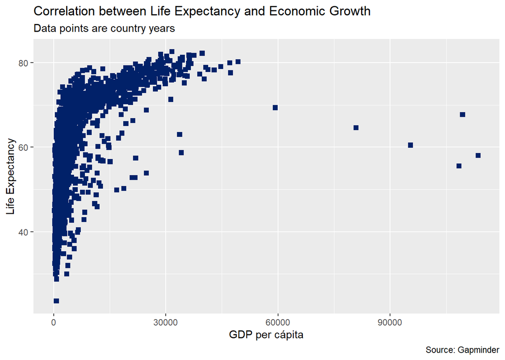

```r
p1 <- ggplot(data= gapminder,                              # dataset you want to use
            mapping = aes(x = gdpPercap, y = lifeExp)) +   # axis
   geom_point(shape = 15,                                  # Shape of the points, try these numbers 0, 1, 2, 3, 4, 10, 14
              color = "#012169",                           # color, you can write the color or use a hex number
              size = 2) +                                  # size of the dots
   labs(x = "GDP per cápita",
        y = "Life Expectancy",
        title = "Correlation between Life Expectancy and Economic Growth",
        subtitle = "Data points are country years",
        caption = "Source: Gapminder")
p1
```

6. We can also change coordinates and scales. Use *coordflip()* to flip coordinates, use *scale_x_log10* to change the scaling into a logarithmic function

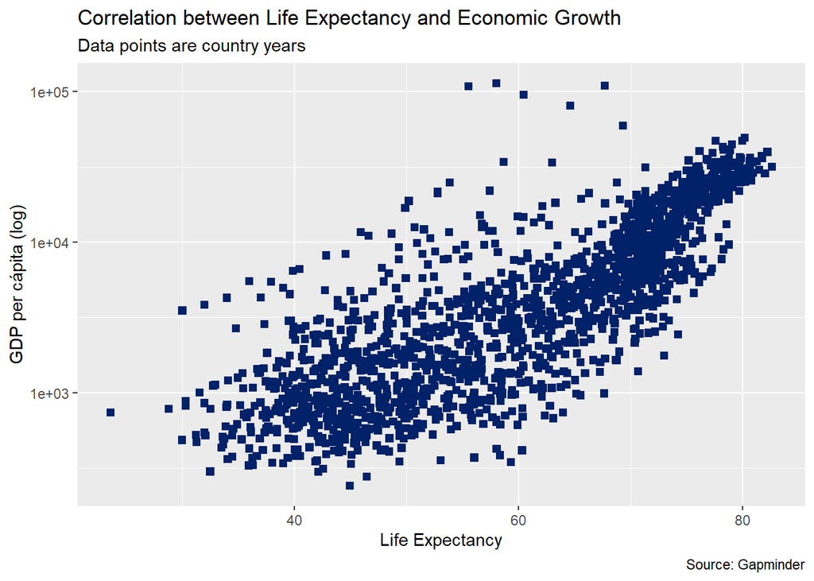

```r
p1 <- ggplot(data= gapminder,                              # dataset you want to use
            mapping = aes(x = gdpPercap, y = lifeExp)) +   # axis
   geom_point(shape = 15,                                  # Shape of the points, try these numbers 0, 1, 2, 3, 4, 10, 14
              color = "#012169",                           # color, you can write the color or use a hex number
              size = 2) +                                  # size of the dots
   labs(x = "GDP per cápita (log)",
        y = "Life Expectancy",
        title = "Correlation between Life Expectancy and Economic Growth",
        subtitle = "Data points are country years",
        caption = "Source: Gapminder") +
   coord_flip() + scale_x_log10()                          # Flip coordinates and change scale for the x axis
p1
```

6. Lastly, we can change the theme in case we want to change the background and font for a pre-designed set. Play with the options you have.

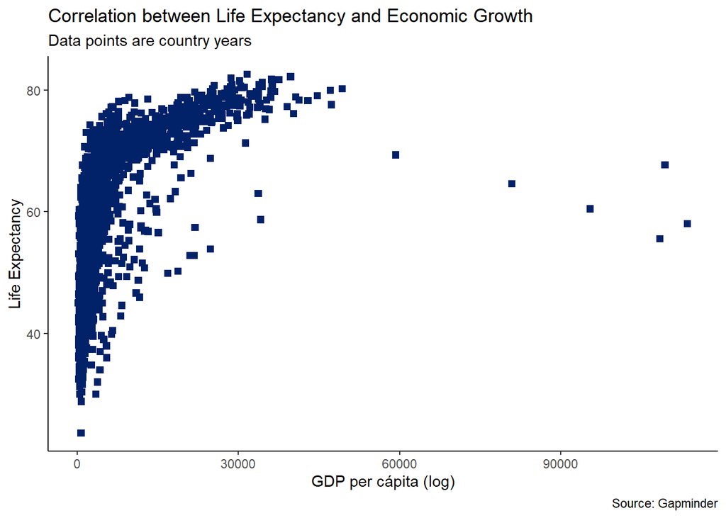

```r
p1 <- ggplot(data= gapminder,                              # dataset you want to use
            mapping = aes(x = gdpPercap, y = lifeExp)) +   # axis
   geom_point(shape = 15,                                  # Shape of the points, try these numbers 0, 1, 2, 3, 4, 10, 14
              color = "#012169",                           # color, you can write the color or use a hex number
              size = 2) +                                  # size of the dots
   labs(x = "GDP per cápita (log)",
        y = "Life Expectancy",
        title = "Correlation between Life Expectancy and Economic Growth",
        subtitle = "Data points are country years",
        caption = "Source: Gapminder") +
   theme_classic()
p1
```

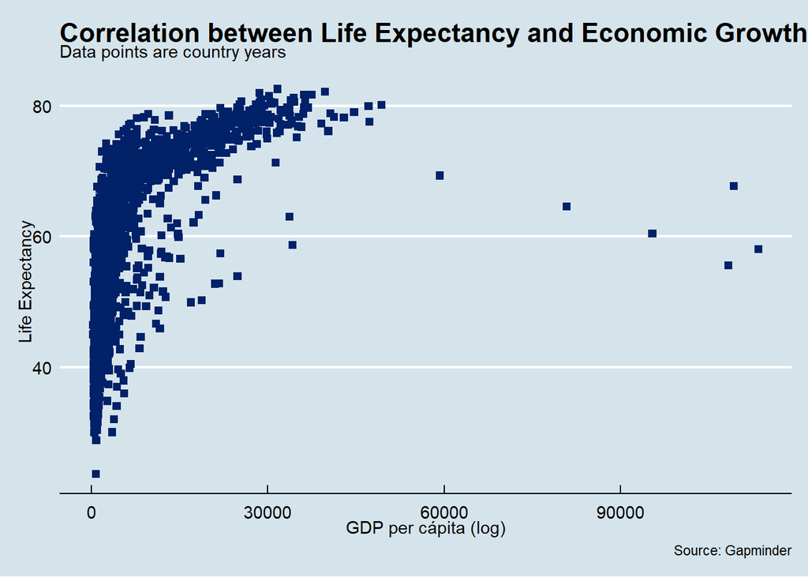

```r
# For The Economist we need to install and call a new library
library(ggthemes)
p1 <- ggplot(data= gapminder,                              # dataset you want to use
            mapping = aes(x = gdpPercap, y = lifeExp)) +   # axis
   geom_point(shape = 15,                                  # Shape of the points, try these numbers 0, 1, 2, 3, 4, 10, 14
              color = "#012169",                           # color, you can write the color or use a hex number
              size = 2) +                                  # size of the dots
   labs(x = "GDP per cápita (log)",
        y = "Life Expectancy",
        title = "Correlation between Life Expectancy and Economic Growth",
        subtitle = "Data points are country years",
        caption = "Source: Gapminder") +
   theme_economist()
p1
```

As you see, you can have a lot of control over the graphics you want to present in your papers. Play around with this code changing options and defaults to produce graphs that fit both your aesthetic and your communication goals. There are some additional sources at the end to explore more changes to graphs. I will not go into changes in the facet since it can become complicated. Some code will be given as an example later in case you want to see how it works. We now change our attention to one-variable graphs. You can also save your graph using the ggsave command. Make sure you set your directory (*setwd*) at the start of your R file.

```r
ggsave(filename = "scatter.png", plot = p1)
```